# Grunnskole, videregående utdanning og høyere utdanning

Kapittel 10 og 11 i Barr

Mikko Moilanen

2026-02-03

# Kapittel 10 og 11: Grunnskole, videregående utdanning og høyere utdanning

## 10.1 Introduksjon

- Kapittel 10, om **grunnskoleutdanning og vg**, og Kapittel 11, om **høyere utdanning**, må ses i sammenheng
  - økonomisk teori gir forskjellige konklusjoner om statens rolle
  - NB! Equity-begrepet er vanskelig å oversette til norsk
    - equality: kan oversettes med likhet
    - equity: like muligheter eller lik tilgang

## Utdanningsnivå i Norge og verden

[interactive chart not shown]

## Målet med utdanning

- samfunnets velferd maksimeres gjennom å øke effektivitet og sosial rettferdighet

### Grunnskole og vg

- hovedmålet: å oppnå bedre utdanningsresultater
  - kilder til bedre utdanningsresultater:
    - inntekt / formue
    - individuelle valg
    - foreldre
    - medelever/-studenter
    - innfødte evner
- delmål: å overføre
  - kunnskaper og ferdigheter, *og*
  - holdninger og verdier
  - felles kunnskapsbase, felles verdier – mer sosial kohesjon

### Spesifikke mål for høyere utdanning

- å fremme intellektuell frihet og mangfold
  - mindre vekt på sosial kohesjon
- jakten på kunnskap for sin egen skyld
- idéfrihet

## Instrumentelle mål: effektivitet og rettferdighet

### Effektivitet

- kostnader ved utdanning kan måles
  - [De samlede omkostninger, som en student ville være belastet av i fraværet av offentlig støtte i Danmark i 2019 i danske kroner](https://cepos.dk/media/6202/notat_er-hoejere-uddannelse-oversubsidieret.pdf) - direkte kostnader 59.927 - studiestøtte (etter skatt) 64.418 - alternativinntekt (etter skatt) 235.577 - øvrige kostnader 10.000 - i alt 369.922
- nytten er bred og vanskelig å kvantifisere
  - **konsumnytte** - man kan nyte selve utdanningsprosessen
    - **investeringsnytte**
      - høyere lønn
      - større arbeidsglede
      - større nytelse av fritid
    - positive eksternaliteter (mer om dette senere)
- Vanskelig å fastslå kausal effekt (evner vs. utdanning)
- Utdanning øker arbeidsstyrkens kvalitet, og mange studier finner positiv veksteffekt

[interactive chart not shown]

### Rettferdighet

- Like muligheter betyr ikke likt utfall (flaks, preferanser, evner)
- Grunnutdanning finansiert via skatt → progressiv
- Høyere utdanning kan bli regressiv
- Tidlige forskjeller og familieforhold påvirker utdanningsløpet

**Konklusjon:** **Utdanning kan styrke både effektivitet og rettferdighet, men effektene er vanskelige å isolere, og fordelingsvirkningene avhenger av finansiering og faktisk tilgang**.

## 10.3.1 Teoretiske argumenter for offentlig inngrep av effektivitetsgrunner: markedssvikt i utdanning

## Ufullkommen informasjon

**Grunnskole og vg**

- i en situasjon der markedet får fungere alene (kun private beslutninger styrer utfallet):
  - barn er ikke godt informert
  - foreldrene bestemmer
    - bare delvis informert f.eks. om kvalitet

**Høyere utdanning**

- i en situasjon der markedet får fungere alene:
  - studentene er velinformerte
    - det er mer sannsynlig at studentene gjør bedre valg for seg selv enn staten hadde gjort
    - studenter er bedre enn staten til å gjøre valg som samsvarer med deres egne og samfunnets behov etter hvert som elevene blir eldre (konsumentsuverenitet)
    - **mindre problemer med asymmetrisk informasjon i høyere utdanning**

## Irrasjonell adferd

**Grunnskole**

- i en situasjon der markedet får fungere alene:
  - elever ville hatt problem med **begrenset rasjonalitet** (vet ikke hvilke valg som maksimerer deres nytte over tid)
  - foreldre bestemmer
    - vet foreldre hvilke valg som maksimerer deres barns nytte?
    - foreldre vil kanskje ikke ta hensyn til barnets beste, men familiens beste (lav konsumentsuverenitet)
    - noen familier er i stand til å gjøre bedre valg for sine barn enn staten, noen er ikke det
      - er valgene knyttet til familiens sosioøkonomisk status?

**Høyere utdanning**

- **mindre problem med begrenset rasjonalitet**
  - studentene antas å vite i større grad hvilke valg som maksimerer deres nytte

## Implikasjoner av disse informasjonsproblemer (se [video](https://uit.cloud.panopto.eu/Panopto/Pages/Viewer.aspx?id=d65f6fa3-b577-417a-bbac-b3e100f7ae5b))

- Om bare privat marked skulle tilby utdanning, vil ufullkommen informasjon føre til ineffektivitet
  - problemet ville være større i grunnskole og vg enn i høyere utdanning
    - det er sannsynlig at **ufullkommen informasjon vil føre til lavere forbruk av utdanning enn det optimale nivået for samfunnet, spesielt i lavere sosioøkonomiske grupper**

## Implikasjoner av disse informasjonsproblemer

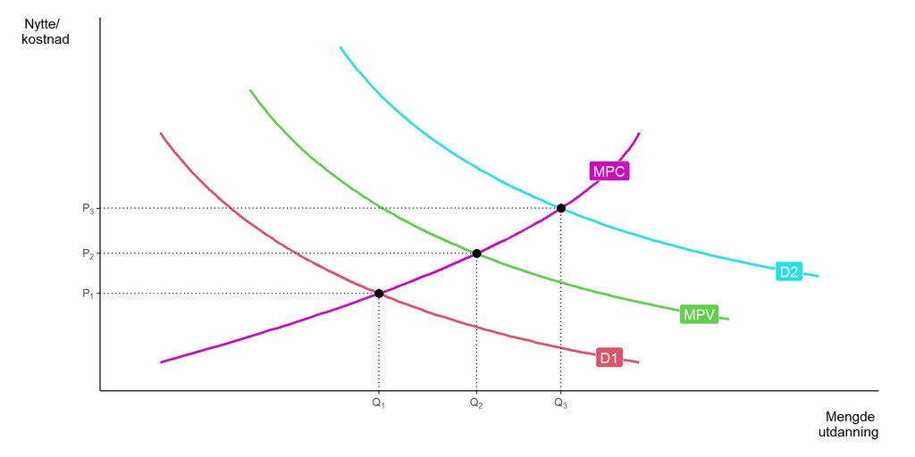

## Positive eksternaliteter

- **positive eksternaliteter i utdanning**
  - de positive effektene som en persons utdanning har på samfunnet som helhet, som den personen ikke blir kompensert for
    - i neoklassisk økonomisk teori vurderer individene kun de **private** fordelene og kostnadene ved å ta en beslutning om å investere i sin egen utdanning
    - men deres utdanning har også positive effekter på samfunnet som helhet
      - økt innbetaling av skatt
      - raskere økonomisk vekst - min utdanning gjør også andre mer produktive
      - bedre respons på økonomisk endring
      - sterkere sosial samhørighet
      - bedre foreldre
      - bra for demokrati
    - dette kan føre til at individene undervurderer verdien av utdanning, og dermed **investerer mindre i utdanning enn det som ville være optimalt for samfunnet som helhet**

## Positive eksternaliteter (se [video](https://uit.cloud.panopto.eu/Panopto/Pages/Viewer.aspx?id=588f8515-a9d5-4415-bd40-b3e100f7ae72))

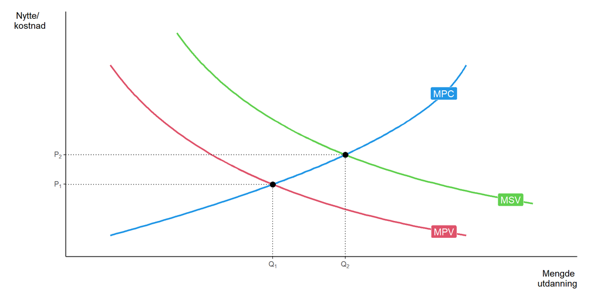

## Positive eksternaliteter

**Grunnskole**

- utdanning vil gi både eleven privat nytte og nytte for samfunnet
  - i et rent privat markedssystem:
    - ** elever ville investert mindre i utdanning enn det som ville være optimalt for samfunnet som helhet**

**Høyere utdanning**

- høyere utdanning gir (vanligvis) **mye mer privat nytte** enn grunnskoleutdanning
  - høyere inntekt
  - mer tilfredsstillende jobber
  - større glede av fritiden
- i et rent privat markedssystem:
  - studenter ville ha **investert mindre i utdanning enn det som ville være optimalt for samfunnet som helhet**

## Manglende markeder og ufullstendige kontrakter

**Manglende markeder**

- **Høyere utdanning**
- markedet for utdanningsfinansiering (studielån) er imperfekt
  - studenter som ønsker å låne kan ikke tilby fysisk eller økonomisk sikkerhet
  - i et rent markedssystem vil dette føre til **underinvestering i humankapital**
    - uheldig både for den enkelte og for samfunnet som helhet
      - særlig for lavere samfunssøkonomiske grupper
    - mange studenter ville ikke hatt tilgang til nødvendig finansiering for å dekke kostnadene, inkludert levekostnader
    - ville vært en betydelig barriere for mange potensielle studenter
  - mangelen på sikkerhet er årsaken til det imperfekte markedet for studielån
    - når noen kjøper et hus
      - hen vet hva hen kjøper
      - det er lite sannsynlig at huset faller sammen
      - verdien av huset vil sannsynligvis gå opp
      - hvis lånetakerens inntekt faller uventet, kan han vanligvis selge huset for å betale tilbake lånet
    - når noen skal ta utdanning
      - høy risiko (eller i det minste en oppfattet høy risiko, som igjen er høyere for personer uten tidligere universitetserfaring i familien) for å ikke bli ferdig
      - hvis lånetakerens inntekt faller uventet, er det ingen mulighet til å selge graden for å betale tilbake lånet
      - selv om gjennomsnittlig privat avkastning for utdanning er positiv, er det betydelig variasjon rundt den
    - det er ingen sikkerhet for lånet

## Ufullstendige kontrakter

- vanskelig å spesifisere alt i kontrakt
  - for eksempel kan en kontrakt mellom en skole og en elevs foreldre spesifisere kostnader, varighet av kurset, og andre grunnleggende vilkår, men den kan være ufullstendig med hensyn til å spesifisere kvaliteten på undervisningen som skal gis, kvalifikasjonene til lærerne osv.

## Ufullkommen konkurranse

**Grunnskole**

- i et rent markedssystem: skoler i byer ville hatt konkurranse, men en rural skole ville hatt et lokalt monopol –> vil produsere mindre enn optimalt for samfunnet

**Høyere utdanning**

- mange universiteter og høyskoler
- elevene kan være mobile
- fjernundervisning
- i et rent markedssystem: det ville vært mer konkurranse i høyere utdanning enn i grunnskoleutdanning

## 10.3.2 Teoretiske argumenter for offentlig inngrep: rettferdighet

- horisontal likhet
  - “lik tilgang til utdanning”
    - individer fra lavere samfunnsklasser har dårligere råd
    - foreldre fra lavere sosioøkonomiske grupper kan ha mindre informasjon om skolevalg
    - de kan også være mindre i stand til å bruke denne informasjonen
    - kostnader for å innhente informasjon kan også være høyere
  - det er betydelig forskjeller i tilgang til skolegang av høy kvalitet og til informasjon om fordelene med en utdanning
    - dermed er det hovedsaklig folk fra høyere samfunnslag som går på universitetet
- Én person med vanskeligstilt bakgrunn er da mer sannsynlig
  - å bli dårlig informert om fordelene ved å studere på universitetet
  - å gå på en dårligere grunnskole
- men… siden de fleste studenter er fra høyere samfunnslag, vil **100% skattefinansiert høyere utdanning fungere regressivt**

## 10.3.3 Ulike typer av **offentlige inngrep** av effektivitetsgrunner

## Offentlige inngrep ved informasjonsproblemer og manglende rasjonalitet

**Grunnskole**

- private valg er effektive bare hvis familier har tilstrekkelig informasjon og om de bruker denne informasjonen til barnets beste
  - **inngrep: regulering**
    - obligatorisk skolepliktig alder (for å forhindre underforbruk)
  - det offentlig er mer effektiv enn privat sektor i kvalitetskontroll:
    - læreplan
    - kvalifikasjonskrav for lærere
    - skolegodkjenninger
  - **inngrep: informasjonsformidling**

**Høyere utdanning**

- **inngrep**:
  - **informasjonsformidling**:
    - Samordna opptak, Studiebarometeret osv.
  - **regulering**
    - tilsyn og evalueringer av institusjonene og deres studieprogrammer
    - kvalifikasjonskrav
    - godkjenninger

## Offentlige inngrep ved positive eksternaliteter

**Grunnskole**

- 100 % offentlig subsidiering av utdanning

**Høyere utdanning**

- offentlig subdisiering av utdanning
- økonomiske subsidier til studenter (stipend og studielån)
- høyere utdanning gir (vanligvis) mye mer *privat nytte* enn grunnskoleutdanning
  - det er effektivt (paretooptimalt) at studenter bærer en del av kostnadene

## Positive eksternaliteter og subsidiering (se [video](https://uit.cloud.panopto.eu/Panopto/Pages/Viewer.aspx?id=bdae9fe8-66d1-48b5-b7aa-b07700b543a4))

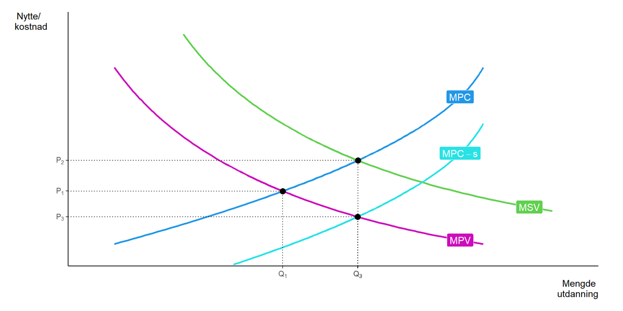

## Offentlige inngrep ved ufullkomne kapitalmarkeder

**Høyere utdanning**

- Statens lånekasse for utdanning (Lånekassen)
  - tilbyr lån og stipender til studenter for å hjelpe dem med å finansiere sin høyere utdanning
    - gunstige vilkår
      - lav rente
      - ingen krav til sikkerhet
      - fleksible tilbakebetalingsbetingelser

## 10.3.3 Ulike typer av **offentlige inngrep** av rettferdighetsgrunner

**Grunnskole og videregånde**

- like muligheter
  - **subsidiering av utdanning** sikrer lik tilgang til utdanning og fremmer sosial mobilitet
  - **gi bedre informasjon** (for å bistå rasjonelle valg)
    - disse problemene kan være større for individer i lavere sosioøkonomiske grupper
    - foreldre med lite utdanning har mindre informasjon om skolevalg enn bedre utdannede foreldre
    - i tillegg kan de være mindre i stand til å utnytte informasjonen de faktisk får tak i

**Høyere utdanning**

- **subsidiering** av utdanning **sikrer lik tilgang** til utdanning og fremmer sosial mobilitet
- **gi bedre informasjon**: hvis ikke alle er like godt informert og ikke har en like god skoleutdanning
- inngrep for å fremme tilgang til høyere utdanning av rettferdighetsgrunner i stor grad er berettiget av ulikhet tidligere i systemet
- mye av intervensjonen bør skje under tidligere utdanning

## Offentlig produksjon, allokering og finansiering? Ja

- Disse problemene dreier seg avgjørende om svarene på to spørsmål
  - Gjør foreldre bedre eller dårligere beslutninger enn staten om barnas utdanning?
    - svaret er empirisk
    - libertarianere:
      - hevder at offentlig inngrep forstyrrer foreldrenes frihet
    - demoratiske sosialister:
      - målet om likhet er overordnet
        - kravet fra barn fra fattigere familier prioriteres
      - offentlig allokering foretrekkes både for å sikre at barn med dårligere bakgrunn går på en god skole og for å sikre en elevsammensetning som oppmuntrer til utdanning og fremmer sosialt samhold
    - liberale
      - prøver å anerkjenne kravene til begge grupper
      - et system enten basert på offentlig allokering, som tar noe hensyn til foreldrenes preferanser, eller basert på foreldrenes valg som overvåkes nøye

## Lærdommer fra økonomisk teori

**Grunnskole og videregående**

- markedssviktene tilstrekkelig store til å gjøre **offentlig produksjon og finansiering** mer effektiv enn det private markedet hadde klart
- **regulering** pga. ufullkommen informasjon, irrasjonell adferd, ufullstendige kontrakter, og tilstedeværelsen av eksternaliteter og lokale monopoler
- **subsidiering** pga. store positive eksternaliteter
- spørsmålet om *offentlig produksjon* hviler i stor grad på omfanget av informasjonsproblemer fra barn og foreldre, og på om kvalitet overvåkes mer effektivt i offentlig sektor
- et rent markedsystem ville sannsynligvis vært **svært ineffektivt og også urettferdig** i den grad både kunnskap og tilgang til kapitalmarkeder er korrelert med sosioøkonomisk status
- et rent privat markedsdssystem som tilbyr grunnskole- og videregående utdanning er teoretisk usannsynlig, og eksisterer i praksis ikke i noe land

**Høyere utdanning**

- informasjonsproblemer er mindre - mindre inngrep
- nyutdannede (ikke studenter) bør bidra til kostnadene for utdanning
  - effektivitetsgrunner - høyere utdanning skaper en rekke **positive eksternaliteter for samfunnet**, som rettferdiggjør støtte fra skattebetalerne
    - høyere utdanning gir (vanligvis) mye mer **privat nytte** enn grunnskoleutdanning
      - effektivt og rettferdig at studentene bærer en del av kostnadene
        - de bør bære disse kostnadene når de har råd
          - som uteksaminerte, ikke når de er studenter
  - Konkurranse i høyere utdanning, passelig regulert, kan være fordelaktig
    - empirisk ser det ut til at konkurrerende systemer for høyere utdanning gir høyere kvalitet, i det minste målt ved verdensrangeringer
- Studielån
  - tilbud av lån som følge av ufullkomne kapitalmarkeder
    - bør ha inntektsavhengige tilbakebetalinger
      - beskytter låntakere mot risikoer
      - ville ellers føre til ineffektivt lave investeringsnivåer i humankapital
      - forbedrer også rettferdigheten
    - lånet bør være stort nok til å dekke studieavgifter og levekostnader, **noe som gjør høyere utdanning gratis ved bruk**
    - lån bør ha en rente som tilsvarer statens lånekostnader
    - rettferdighetsgrunner